# Part B. Computing a language fractionalization index

```r
# change country_code into country name
data_merge_tp$country_name <- countrycode(data_merge_tp$country_code, origin = "iso2c", destination =  "country.name")

# convert data to the target format,rename cols, delete unwanted cols
data_merge_tp$language <- as.numeric(data_merge_tp$language)
data_merge <- subset(data_merge_tp, select = -c(country.x,country.y))%>%
  rename(index_alesina_et_al. = language,
         index_tweets = country_frac )


# check the files
head(data_merge)
```

```
##   country_code index_alesina_et_al. index_tweets         country_name
## 1           AD               0.6848    0.5955556              Andorra
## 2           AL               0.0399    0.6734694              Albania
## 3           AT               0.1522    0.6692610              Austria
## 4           BA               0.6751    0.8642659 Bosnia & Herzegovina
## 5           BE               0.5409    0.7401167              Belgium
## 6           BG               0.3031    0.7002984             Bulgaria
```

4. Compare your new metric with the measure on language fractionalization from Alesina et al. What is the correlation between the two? For which sets of countries/observations do you find differences and similarities? Can you conjecture why? Do correlations between the two indices increase if you only look at countries with at least certain numbers of recorded tweets in the data? Use any statistical or graphical methods you find helpful to answer this question. (7 points)

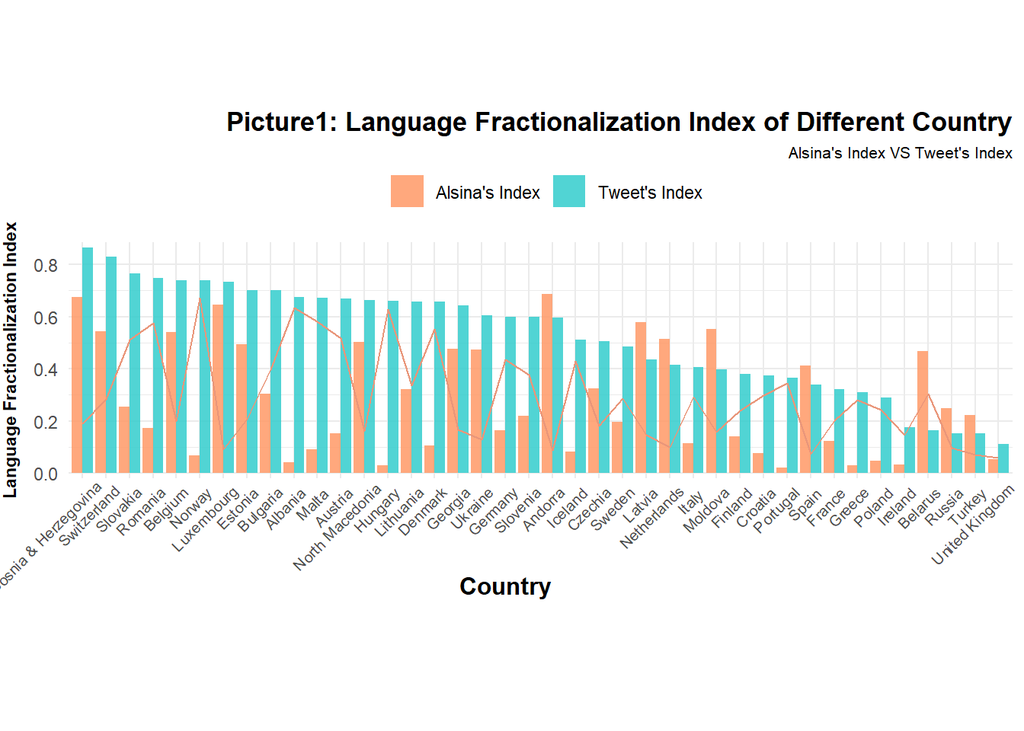

```r
# create a new table that counts countries and the total number of tweets collected
data_sum <- data_CL %>%
  group_by(country_code) %>%
  summarise(tweets_collected = sum(n_tweets))

# Synthesizes a new table containing the elements needed to draw the plot
data_merge_n <- merge(data_merge, data_sum, by = "country_code") %>%
  # ranking the number of tweets captured from least to most,
  # delete the NA countries
  filter(country_name != c("Jersey","Isle of Man")) %>%
  # add a column to calculate the gap between our data and the scientists' data
  mutate(gap = abs(index_tweets - index_alesina_et_al.))

data_merge_fl <- data_merge_n %>%
  arrange(index_tweets) %>%
  mutate(number = order(index_tweets))


# tidy the data
data_merge_plot <- pivot_longer(data_merge_fl,
                                cols = colnames(data_merge_n)[2:3],
                                names_to = "data_source",
                                values_to = "data")
# draw the plot
P1 <- ggplot()

# draw the col-graph to show the values for different countries based on the two tables
P1 + geom_col(data = data_merge_plot,
              alpha = 0.85,
             # sort the country by the index_tweets
             mapping = aes(x = reorder(country_name, -number),
                           y = data,
                           fill = data_source),
             # draw the cols saperately
             position = position_dodge())+

  # fill different colours for different data sources(tables)
  scale_fill_manual(values = c("#ff9966", "#33cccc"),
                     labels = c("Alsina's Index", "Tweet's Index")) +

  # draw a line—graph to show the change in their gap
  geom_line(data = data_merge_plot,
            # sort the country by the index_tweets
            mapping = aes(x = reorder(country_name, -number),
                          y = gap,
                          group = 1),
            colour = "#E9967A",
            size = 0.5) +

  # label, theme, background and other settings
  scale_x_discrete("Country") +
  scale_y_continuous("Language Fractionalization Index", expand = c(0, 0.02)) +
  ggtitle("Picture1: Language Fractionalization Index of Different Country",
          subtitle = "Alsina's Index VS Tweet's Index") +
  theme_minimal() +

  # setting graph elements
  theme(axis.text.x = element_text(size = 7.5,
                                   hjust = 0.9,
                                   angle = 45),
        axis.title.y = element_text(vjust = 3.5,
                                    family = "Times",
                                    size = 8.5,
                                    face = "bold"),
        axis.title.x = element_text(family = "Times",
                                    size = 12,
                                    vjust = 8,
                                    hjust = 0.46,
                                    face = "bold"),
        plot.title = element_text(hjust = 1,
                                  family = "Times",
                                  face = "bold",
                                  vjust = -1),
        plot.subtitle = element_text(size = 8,
                                     hjust = 1,
                                     vjust = -2),
        aspect.ratio=1/4,
        legend.title = element_blank(),
        legend.position = "top")
```